# Hypothesis Testing

#### c) Does score accuracy on the triangular model task (testing phase) differ significantly between scaffold groups?

> After answering the first five questions (learning phase) with scaffolds, participants continued on to answer 10 progressively more complex questions without scaffolds. Without scaffold assistance, the graphs viewed by each group were identical. Although this means the information processing demands are the same across groups, we expect the score for the testing phase will differ significantly based on how well the scaffold facilitated the participant’s learning of the graph system.  
> Accuracy for the testing phase [0,10] of the triangular model task differed significantly between scaffold groups, F(1,163) = 19.07, p < 0.001, r = 0.32, a medium effect. The highest scores were earned by the interactive depiction group (M = 7.22, SD = 2.02), followed by static depiction (M = 6.53, SD = 3.39), data description (M = 6.43, SD = 3.37), visual element description (5.52, SD = 3.03) with the lowest scores earned by the no-scaffold control group (4.17, SD = 3.36).

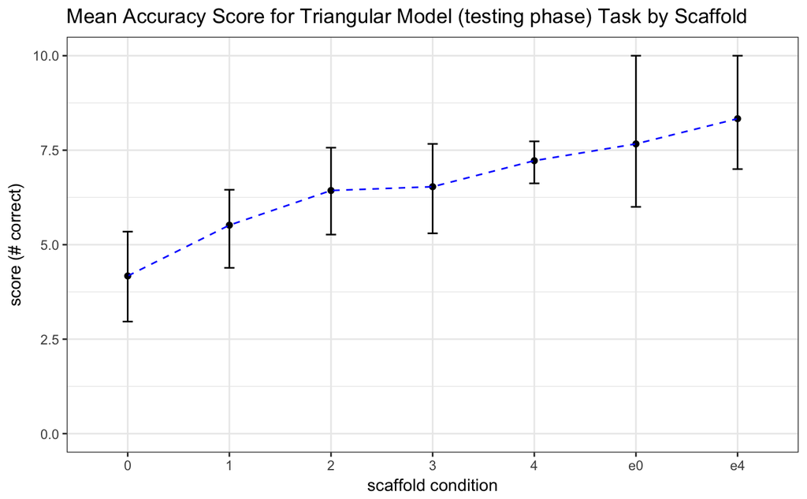

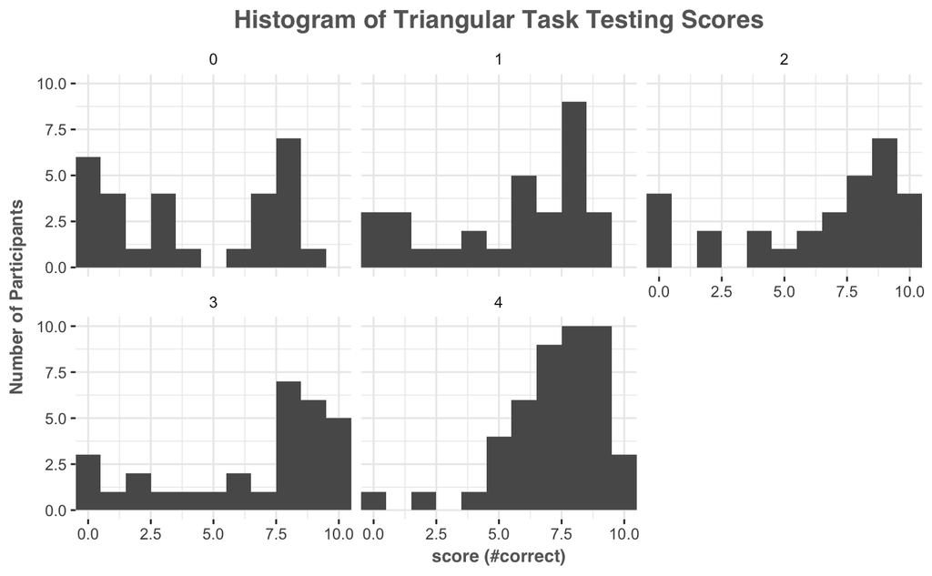

```
w.exp$condition: 0
     nbr.val     nbr.null       nbr.na          min          max        range          sum       median
  29.0000000    6.0000000    0.0000000    0.0000000    9.0000000    9.0000000  121.0000000    3.0000000
        mean      SE.mean CI.mean.0.95          var      std.dev     coef.var
   4.1724138    0.6239651    1.2781345   11.2906404    3.3601548    0.8053264
----------------------------------------------------------------------------------
w.exp$condition: 1
     nbr.val     nbr.null       nbr.na          min          max        range          sum       median
  31.0000000    3.0000000    0.0000000    0.0000000    9.0000000    9.0000000  171.0000000    6.0000000
        mean      SE.mean CI.mean.0.95          var      std.dev     coef.var
   5.5161290    0.5445151    1.1120482    9.1913978    3.0317318    0.5496122
----------------------------------------------------------------------------------
w.exp$condition: 2
     nbr.val     nbr.null       nbr.na          min          max        range          sum       median
  30.0000000    4.0000000    0.0000000    0.0000000   10.0000000   10.0000000  193.0000000    8.0000000
        mean      SE.mean CI.mean.0.95          var      std.dev     coef.var
   6.4333333    0.6152905    1.2584103   11.3574713    3.3700848    0.5238474
----------------------------------------------------------------------------------
w.exp$condition: 3
     nbr.val     nbr.null       nbr.na          min          max        range          sum       median
  30.0000000    3.0000000    0.0000000    0.0000000   10.0000000   10.0000000  196.0000000    8.0000000
        mean      SE.mean CI.mean.0.95          var      std.dev     coef.var
   6.5333333    0.6191082    1.2662185   11.4988506    3.3909955    0.5190299
----------------------------------------------------------------------------------
w.exp$condition: 4
     nbr.val     nbr.null       nbr.na          min          max        range          sum       median
  45.0000000    1.0000000    0.0000000    0.0000000   10.0000000   10.0000000  325.0000000    8.0000000
        mean      SE.mean CI.mean.0.95          var      std.dev     coef.var
   7.2222222    0.3013252    0.6072810    4.0858586    2.0213507    0.2798793
w.exp$condition coerced to factor.
Levene's Test for Homogeneity of Variance (center = median)
       Df F value  Pr(>F)
group   4  2.7877 0.02835 *
      160
---
Signif. codes:  0 ‘***’ 0.001 ‘**’ 0.01 ‘*’ 0.05 ‘.’ 0.1 ‘ ’ 1
             Df Sum Sq Mean Sq F value   Pr(>F)
condition     1  169.5  169.52   19.07 2.23e-05 ***
Residuals   163 1448.9    8.89
---
Signif. codes:  0 ‘***’ 0.001 ‘**’ 0.01 ‘*’ 0.05 ‘.’ 0.1 ‘ ’ 1

Call:
aov(formula = tt_n ~ condition, data = w.exp)

Residuals:
    Min      1Q  Median      3Q     Max
-7.3560 -1.9664  0.7284  2.4231  4.4231

Coefficients:
            Estimate Std. Error t value Pr(>|t|)
(Intercept)   4.5769     0.4184  10.940  < 2e-16 ***
condition     0.6948     0.1591   4.367 2.23e-05 ***
---
Signif. codes:  0 ‘***’ 0.001 ‘**’ 0.01 ‘*’ 0.05 ‘.’ 0.1 ‘ ’ 1

Residual standard error: 2.981 on 163 degrees of freedom
Multiple R-squared:  0.1047,    Adjusted R-squared:  0.09925
F-statistic: 19.07 on 1 and 163 DF,  p-value: 2.232e-05
```

Levene’s is significant therefore should run Robust ANOVA… but anyway… 1 way independent means ANOVA is significant at p < 0.001. Multiple R-squared = eta-squared = 0.1047, so r effect size = sqrt(0.1047) = 0.32.

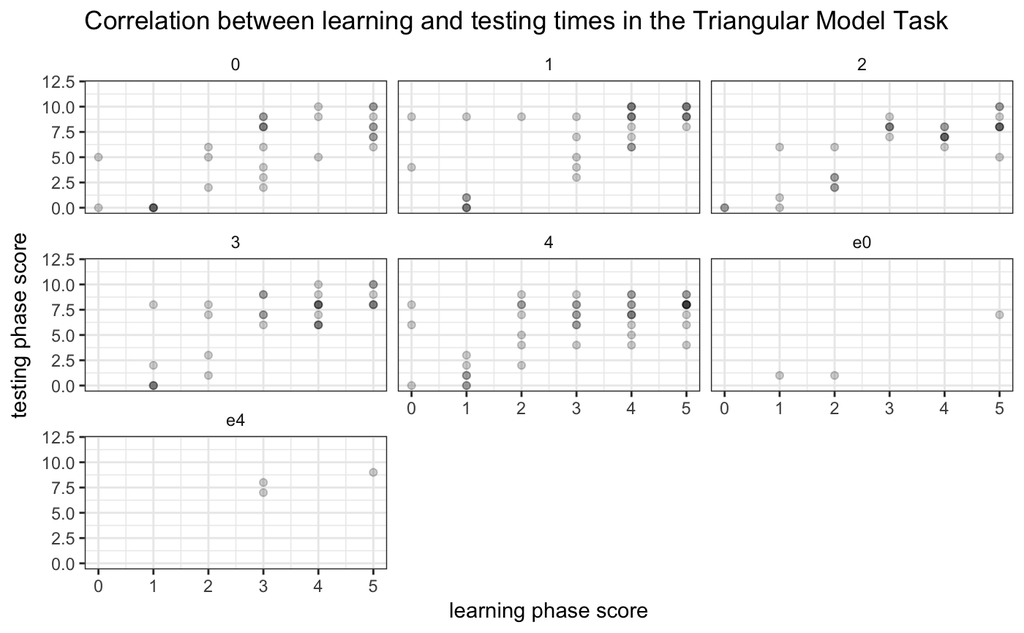

#### d) Does drawing score differ significantly between scaffold groups?

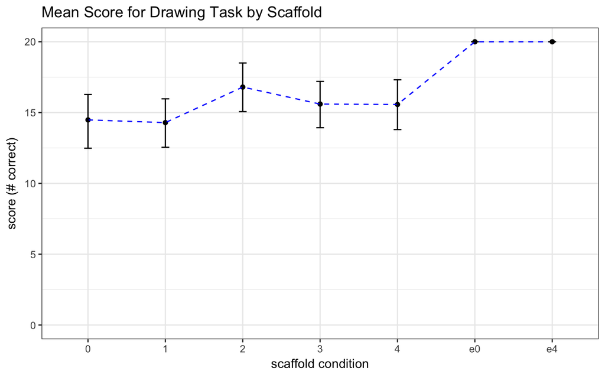

#### e) Is there a relationship between graph interpretation and graph score?

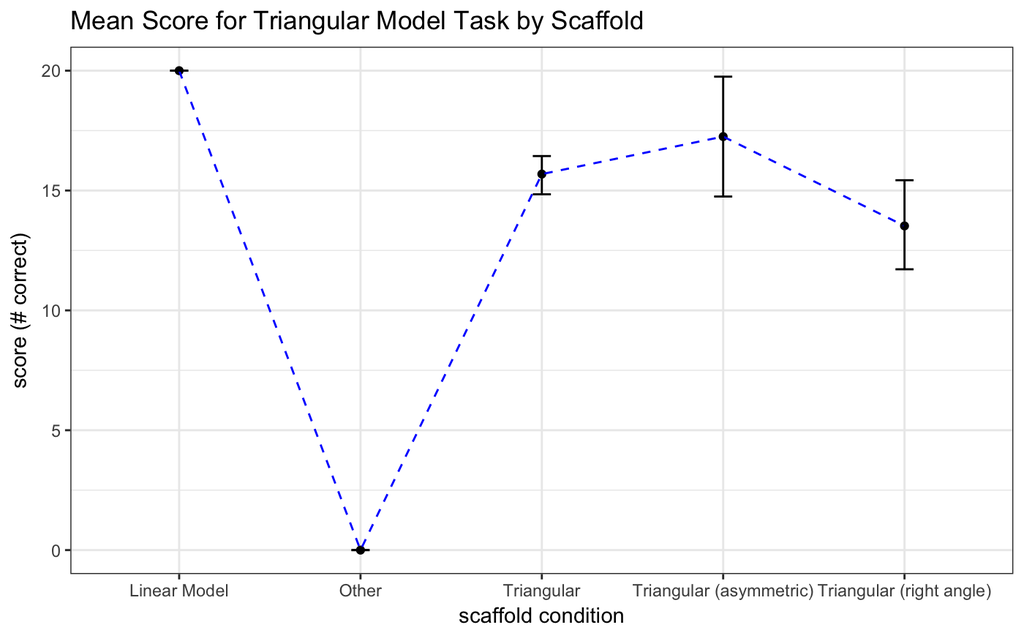